# Agrotóxicos e telômeros

Jaqueline Passos, Karoline Felisbino, Izonete Cristina Guiloski e [Henrique Laureano](https://henriquelaureano.github.io/)

Last modification on* 2022-03-09 14:05:20

# Blue color

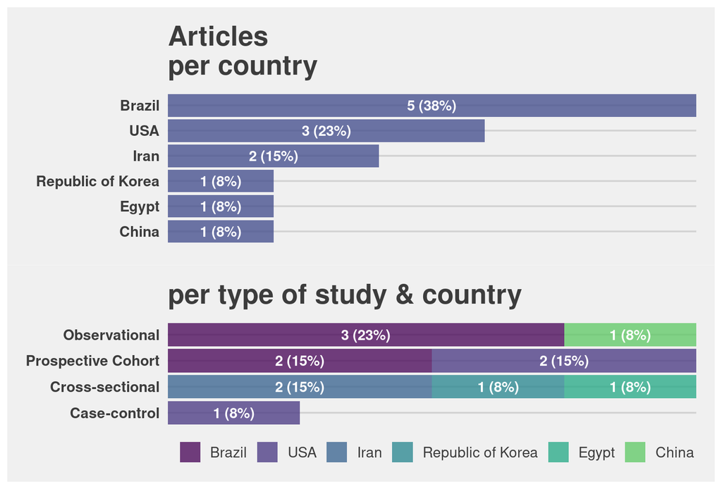

# Skin color

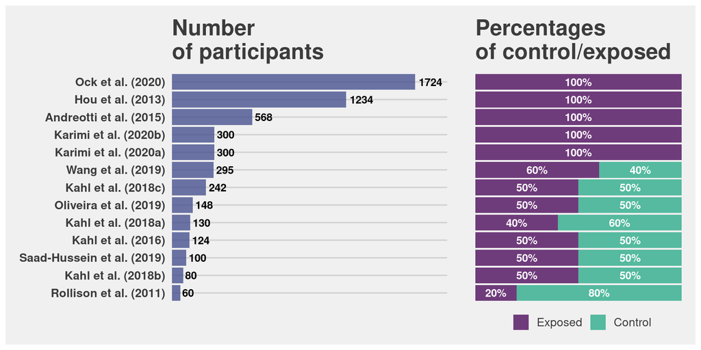

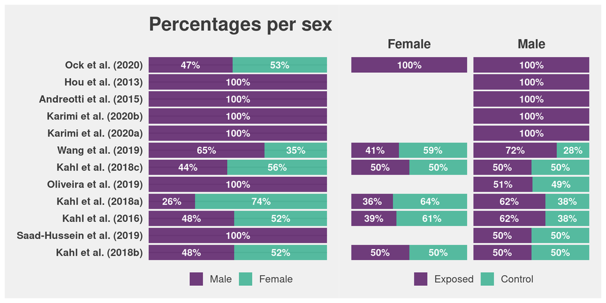

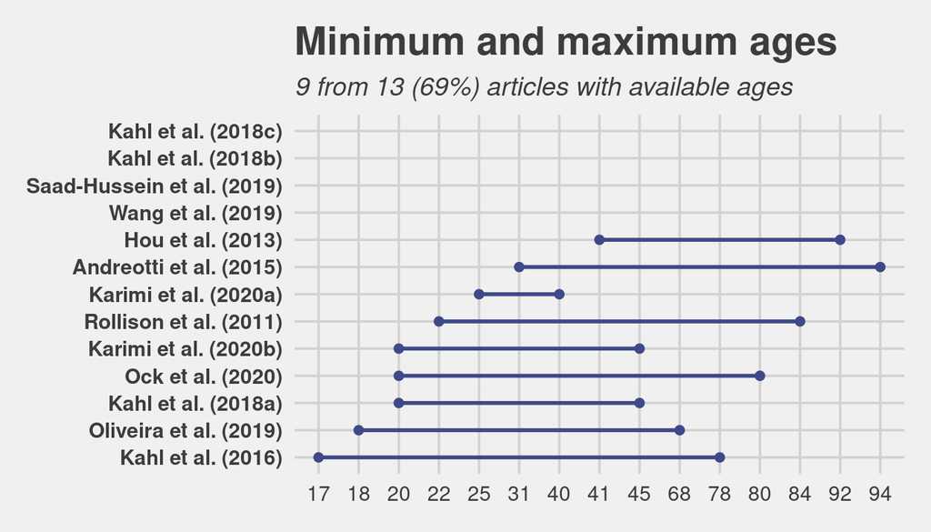

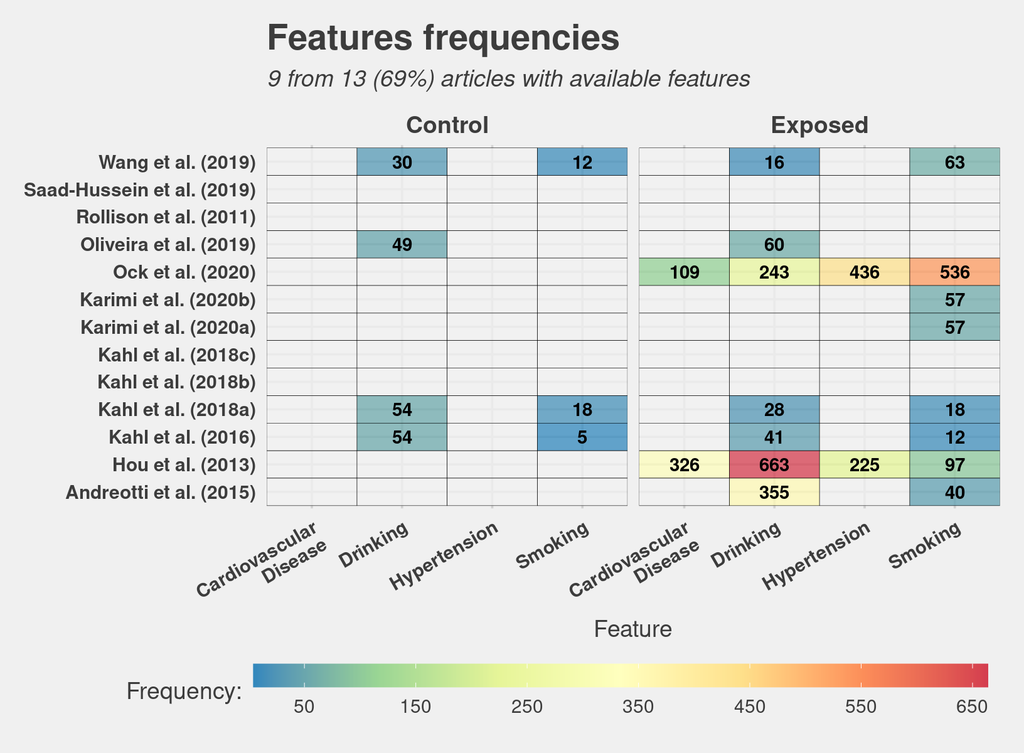

# Light green color

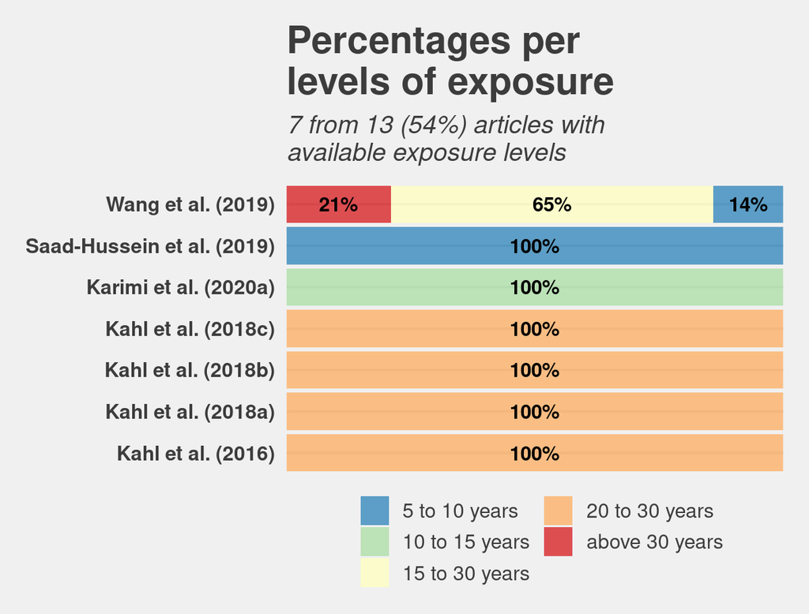

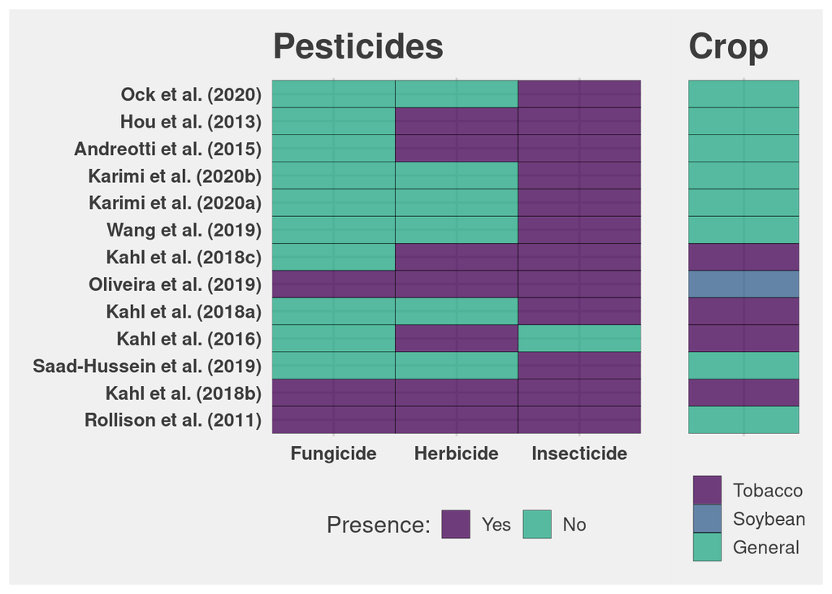

# Pink color (T/S)

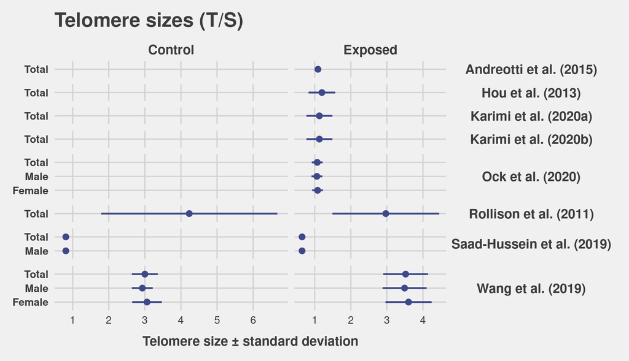

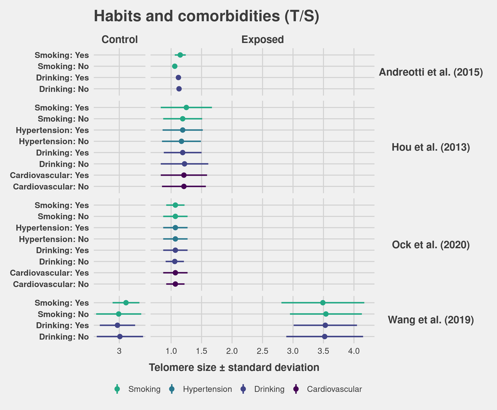

# Green color (bp)

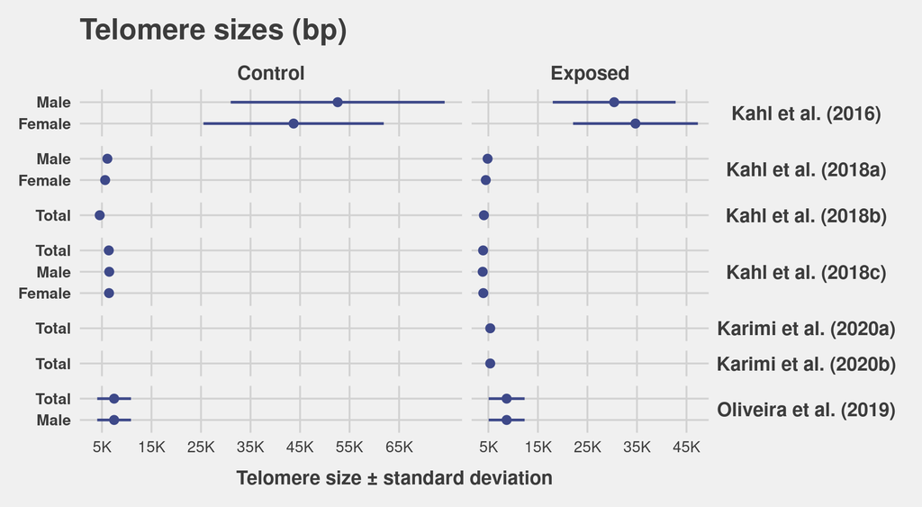

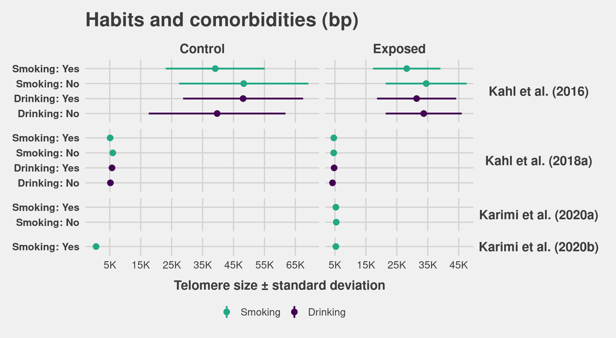

# Meta-analysis

> The chosen measure to model the difference between exposed and control was the **log response ratio** (lnRR)
> $$\text{lnRR} =
> \log (\text{Response Ratio}) =
> \log \Big(\frac{\text{Exposed}}{\text{Control}}\Big).$$

> The log transformation is applied to have a sampling distribution centered around zero (useful to get more reliable *p*-values).

> The standard measures/metrics in a meta-analysis, presented in the following forest plots, are:
> - *Q*: Cochran’s test statistic for the residual heterogeneity, approximated from a chi-square distribution;
> - $Q_{M}$: if the variables/moderators are statistically significant;
> - $I^{2}$: the estimated amount of heterogeneity relative to the total amount of variance in the observed effects.

## T/S

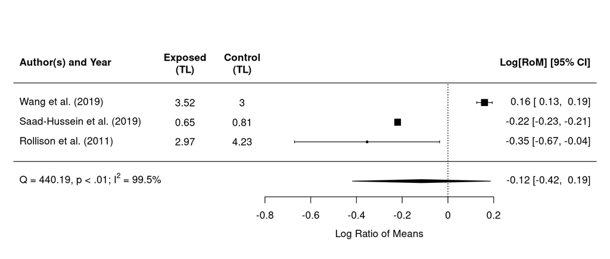

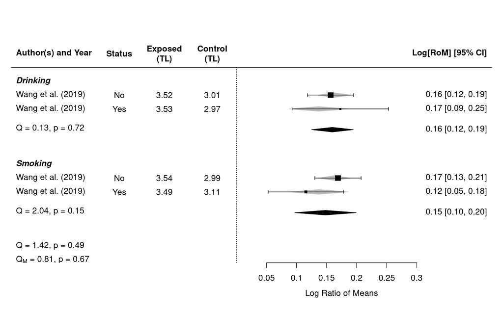

## bp

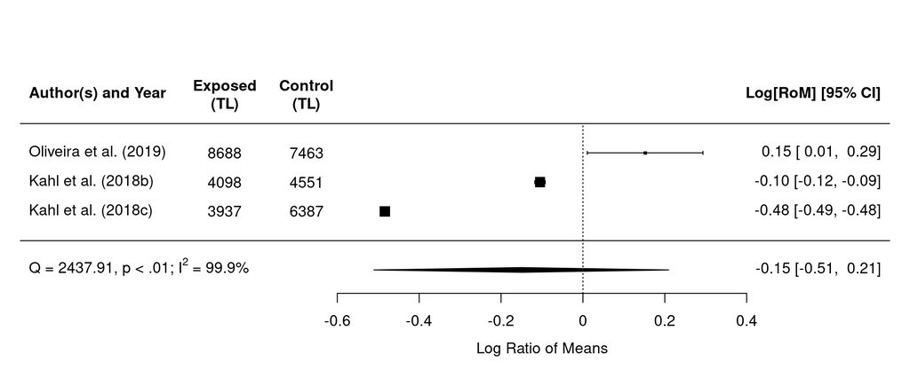

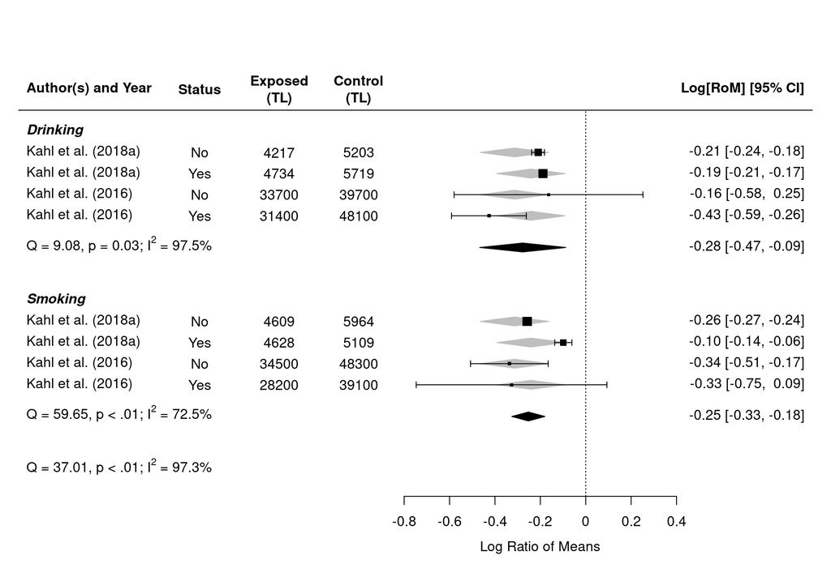

# References

> The statistical analysis was performed with the `R` language and environment for statistical computing (R Core Team, 2021). Barplots, percentage computations, and heatmaps were used to describe and summarize the qualitative variables. Segments, points, and line range plots were used to describe the quantitative variables. A meta-analysis (Viechtbauer, 2010) was performed to understand and summarize the findings of the articles. The main R packages used in this analysis were: {`dplyr`} (Wickham et al., 2021), {`tidyr`} (Wickham, 2021), {`stringr`} (Wickham, 2019), {`ggplot2`} (Wickham, 2016), {`metafor`} (Viechtbauer, 2010), and {`orchaRd`} (Noble, 2022).

> R Core Team (2021). R: A language and environment for statistical computing. R Foundation for Statistical Computing, Vienna, Austria. URL https://www.R-project.org/

> Wickham, H., François, R., Henry, L., Müller, K. (2021). dplyr: A Grammar of Data Manipulation. R package version 1.0.7. https://CRAN.R-project.org/package=dplyr

> Wickham, H. (2021). tidyr: Tidy Messy Data. R package version 1.1.3. https://CRAN.R-project.org/package=tidyr

> Wickham, H. (2019). stringr: Simple, Consistent Wrappers for Common String Operations. R package version 1.4.0. https://CRAN.R-project.org/package=stringr

> Wickham, H. (2016). ggplot2: Elegant Graphics for Data Analysis. Springer-Verlag New York

> Viechtbauer, W. (2010). Conducting meta-analyses in R with the metafor package. Journal of Statistical Software, 36(3), 1-48. https://doi.org/10.18637/jss.v036.i03

> Noble, D. (2022). orchaRd: Orchard Plots and Prediction Intervals for Meta-analysis. R package version 0.0.0.9000.